# Session 1: Connecting to Philippine Genome Server

Apollo Marco Lizano, Ph.D.

2025-01-31

# Operating System for Interactive Sessions

### Generate pub (.pub) and private key pair file

How to do this?

### For macOS or Linux/UNIX-based systems:

Simply open a terminal window. You can do this by searching for “Terminal” in your system’s search bar. A command prompt window should appear, ready for use.

Type:

```bash
ssh-keygen -t rsa -b 2048
```

It will give you a prompt like this:

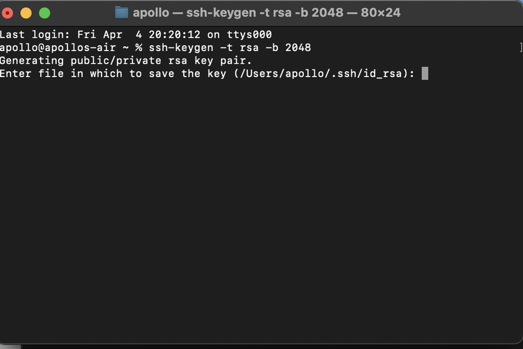

Fig 1. Key generation.

Please give a name to your key (simpler the better) and press Enter.

then it will give you a prompt:

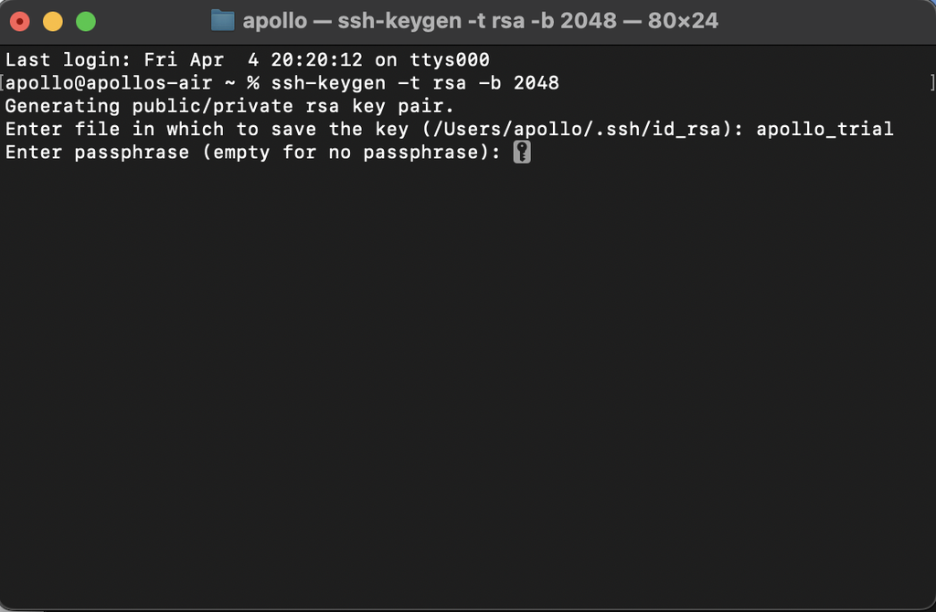

Fig 2. Key passphrase.

Type it twice to match and hit Enter.

*You have now generated your public (.pub) and private key*

Note: the keys are saved in the directory where you are at.

After you have generated your key, please email the public (.pub) key to us at adlizano@msi.upd.edu.ph with the title `key_surname`

### Logging in the PGC server

To log in to the server, use the provided `username` and `key file (not the .pub one)`. Enter the following command:

`ssh -i your_keyfile -p 22222 username@hpc.pgc.up.edu.ph`

Your screen should look like this:

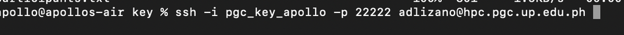

Fig 3. Logging in PGC server.

Click Enter, type your passphrase and you should now end up at your home directory inside the PGC server.

### Let me know if you need any assistance!

### For Windows systems:

Download and install PuTTY from link:[https://www.putty.org/]. Use PuTTY to log in to your Amazon cloud instance.

Open your PuTTY. You should be able to see a GUI like this:

[figure not shown]

Fig 4. PuTTY Graphical User Interface.

#### Step 1: Download and Install PuTTY

If you haven’t installed PuTTY yet, download it from the official website: https://www.chiark.greenend.org.uk/~sgtatham/putty/latest.html

#### Step 2: Open PuTTY

Launch PuTTY on your computer.

### Step 3: Generate your public / private key

Steps to Generate SSH Keys Using PuTTYgen:

3.1 Generate the Key Pair

In Parameters, leave the default settings as:

Type of key to generate: RSA

Number of bits in a generated key: 2048 (or you can set it to 4096 for extra security).

Click the “Generate” button.

Move your mouse around randomly in the blank area to help generate the key.

3.2. Save the Keys

After generation:

Copy the public key from the top text box and save it (or use the “Save public key” button). Email it to us at adlizano@msi.upd.edu.ph with a key word `key_surname`. We need your public key (.pub) for your to be able to login to the PGC server.

Click “Save private key” (the other key)— you may choose to set a passphrase for extra security.

3.3. Using the Keys

Use the private key (file) with PuTTY to log into remote servers.

Send the public key to the system administrator or paste it into the ~/.ssh/authorized_keys file on the server.

To login proceed to the next steps.

#### Step 5: Save the Session (Optional)

To save time in future log ins: In the “Saved Sessions” box, type a name for this connection (e.g., popgen_workshop). Click Save so you don’t have to re-enter details next time. This allows secure authentication without requiring a password each time.

#### Step 5: Upload your private SSH key

In PuTTY, go to the left-hand panel and expand `SSH`, then select `Auth`. Under the `Credentials` section, click Browse and navigate to the folder where your key files are stored (dostbsp_popgen.ppk or just dostbsp_popgen). Select the file and click Open to load the key.

[figure not shown]

Fig 5. Upload SSH key.

[figure not shown]

Fig 6. Upload SSH key.

Sometimes there is no extension file (.ppk), but its the same file

#### Step 6: Log in Using Your Username (we will give you your own username)

A security warning may appear, notifying you about the server’s authenticity. This is a standard precaution to ensure you’re connecting to a trusted server. For this workshop, click `Accept` to proceed.

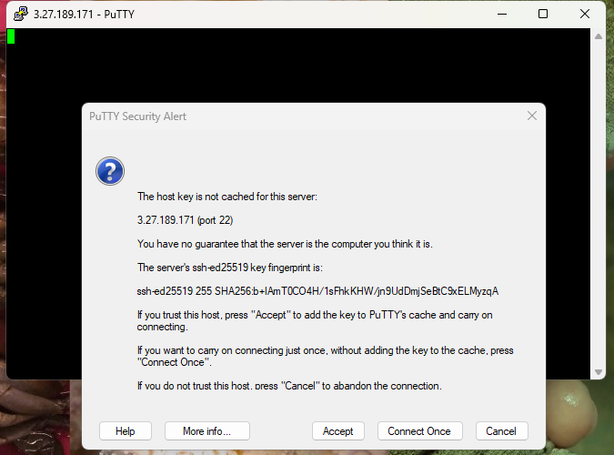

You will then be redirected to a terminal-like window. Here, you will be prompted to enter your username. After typing your username, press Enter to proceed.

[figure not shown]

#### Step 7: Successful Login

[figure not shown]

# Congratulations!!!

### You have successfully accessed a Linux-based server, where we will be conducting our interarctive sessions of bash scripting and prob sets.

Alternatively, you can use the pre-installed Windows PowerShell, which functions similarly to the Linux command line. Note that there are differences in commands between PowerShell and Linux terminals. You can refer to this link:[https://blog.netwrix.com/powershell-commands-cheat-sheet] for guidance.